# Análise de Dados de Contagem de um Experimento Fatorial

EERJ

# 1 Descrição do experimento

Para avaliar a Produtividade de soja sob efeito de umidade do solo e adubação potássica, conduziu-se um experimento fatorial 5 3 (5 níveis de adubação potássica e 3 níveis de umidade do solo). O experimento foi instalado em casa de vegetação no delineamento de blocos casualizados e a unidade experimental foi um vaso com duas plantas de soja. No experimento foram medidas várias respostas, sendo o número de vagens por vaso a variáveis sob estudo nesse documento.

Os dados estão disponíveis no pacote [`MRDCr`](https://github.com/leg-ufpr/MRDCr), disponível no GitHub. Para carregá-los fazemos

```r
# Para instalar o MRDCr: devtools::install_github("leg-ufpr/MRDCr@devel")
data(soja, package = "MRDCr")
str(soja)
```

```
## 'data.frame':    75 obs. of  5 variables:
##  $ K   : int  0 30 60 120 180 0 30 60 120 180 ...
##  $ umid: Factor w/ 3 levels "37,5","50","62,5": 1 1 1 1 1 2 2 2 2 2 ...
##  $ bloc: Factor w/ 5 levels "I","II","III",..: 1 1 1 1 1 1 1 1 1 1 ...
##  $ ngra: int  136 159 156 171 190 140 193 200 208 237 ...
##  $ nvag: int  56 62 66 68 82 63 86 94 86 97 ...
```

```r
soja <- soja[-74, ]
xtabs(~umid + K, data = soja[-74, ])
```

```
##       K
## umid   0 30 60 120 180
##   37,5 5  5  5   5   5
##   50   5  5  5   5   5
##   62,5 5  5  5   4   4
```

## 1.1 Análise exploratória

Na Figura 1.1 são apresentados os gráficos de dispersão das contagens em função dos níveis de adubação potássica para cada nível de umidade do solo.

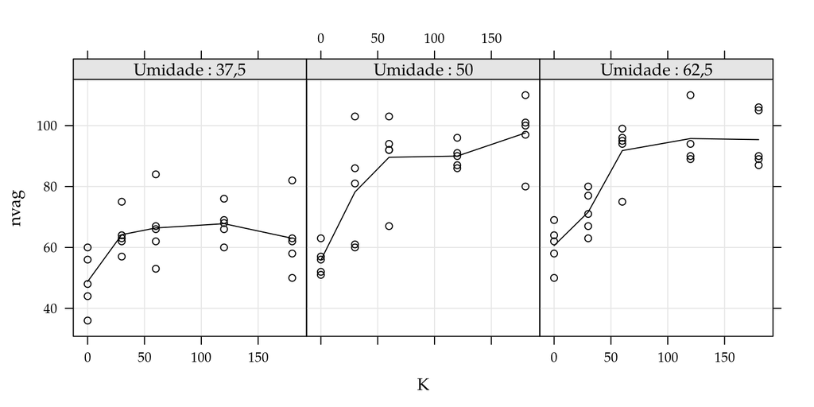

Figure 1.1: Disposição do número de vagens nos diferentes níveis de adubação potássica e umidade do solo.

# 2 Modelagem estatística

Com base no delineamento adotado o seguinte modelo foi proposto

$$\begin{equation}
\begin{aligned}
\texttt{nvag}_{ijk}&\, \mid \, \texttt{bloc}_i,\, \texttt{umid}_j,\,
\texttt{K}_k \sim \text{Poisson}(\mu_{ijk})\\
\log(&\mu_{ijk}) = \beta_0 + \tau_i + \gamma_j + \delta_k + \alpha_{jk}
\end{aligned}
\end{equation}$$

em que

- $\tau_i$ é o efeito do $i$-ésimo bloco;
- $\gamma_j$ é o efeito do $j$-ésimo nível de umidade aplicado;
- $\delta_k$ é o efeito do $k$-ésimo nível de adubação potássica; e
- $\alpha_{jk}$ é o efeito da interação entre o $j$-ésimo nível de umidade do solo e o $k$-ésimo nível de adubação potássica.

Para estimação dos parâmetros utilizou-se da restrição $\tau_1 = \gamma_1 = \delta_1 =$ as demais interação que envolvem os primeiros níveis $=0$. No completo, com interação, são 19 parâmetros a serem estimados.

## 2.1 Ajuste do modelo

Para ajuste dos modelos lineares generalizados em R, utiliza-se a função `glm(...)`, da mesma forma que é utilizada a `lm(...)`, porém necessita especificar a distribuição de probabilidade.

```r
# Transformando os níveis de potássio para fator
soja <- transform(soja, K = factor(K))

# Ajustando o modelo
model <- glm(nvag ~ bloc + umid * K, data = soja, family = poisson)
```

Para a avaliação do ajuste do modelo, pode-se interpretar os gráficos padrão utilizados em modelos lineares, porém com cuidado nas interpretações

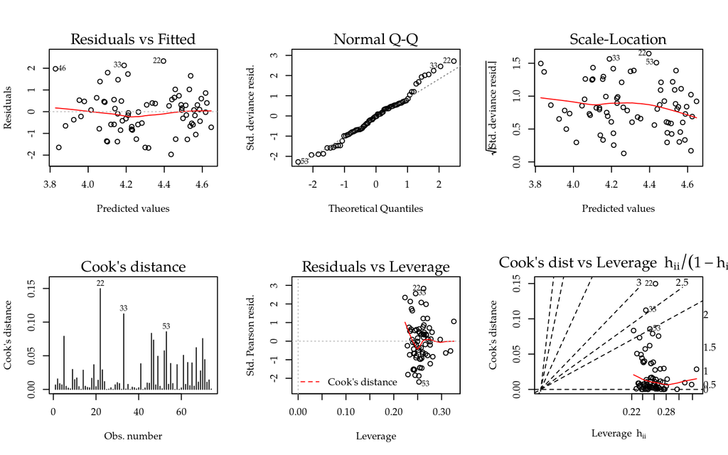

```r
par(mfrow = c(2, 3))
plot(model, which = 1:6)
layout(1)
```

Recomenda-se a avaliação dos gráficos meio-normais com envelope simulado, que simulam $B$ conjunto de dados do modelo ajustado e comparam os quantis 2,5% e 97,5% dos resíduos simulados com os observados. O pacote [hnp](https://cran.r-project.org/web/packages/hnp/index.html) facilita a criação desse gráfico.

```r
# Graico quantil-quantil com envelope simulado
hnp::hnp(model)
```

```
## Poisson model
```

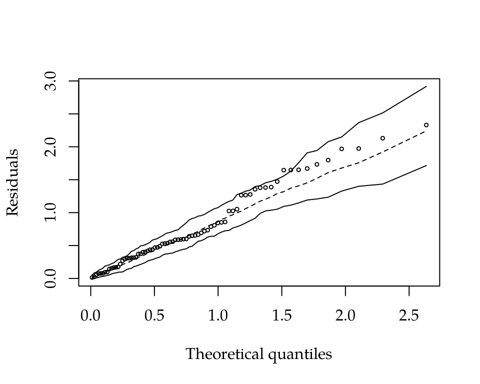

## 2.2 Comparação de modelos

Para comparação sequencial de modelos encaixados, é apresentado abaixo o quadro de análise de *deviance*

```r
# ANODEV
anova(model, test = "Chisq")
```

```
## Analysis of Deviance Table
##
## Model: poisson, link: log
##
## Response: nvag
##
## Terms added sequentially (first to last)
##
##
##        Df Deviance Resid. Df Resid. Dev  Pr(>Chi)
## NULL                      73     322.68
## bloc    4   14.284        69     308.40  0.006442 **
## umid    2   92.911        67     215.49 < 2.2e-16 ***
## K       4  136.060        63      79.43 < 2.2e-16 ***
## umid:K  8   14.150        55      65.28  0.077926 .
## ---
## Signif. codes:  0 '***' 0.001 '**' 0.01 '*' 0.05 '.' 0.1 ' ' 1
```

As estimativas dos parâmetros, seguidos de seus erros padrão e teste de Wald, são obtidos pelo comando `summary(...)`.

```r
# Estimativas e erros padrão
summary(model)
```

```
##
## Call:
## glm(formula = nvag ~ bloc + umid * K, family = poisson, data = soja)
##
## Deviance Residuals:
##     Min       1Q   Median       3Q      Max
## -1.9681  -0.6393  -0.0195   0.4854   2.3306
##
## Coefficients:
##               Estimate Std. Error z value Pr(>|z|)
## (Intercept)    3.95369    0.06892  57.363  < 2e-16 ***
## blocII        -0.02928    0.04091  -0.716  0.47414
## blocIII       -0.07265    0.04136  -1.756  0.07902 .
## blocIV        -0.12544    0.04194  -2.991  0.00278 **
## blocV         -0.10795    0.04297  -2.512  0.01199 *
## umid50         0.13404    0.08765   1.529  0.12619
## umid62,5       0.21656    0.08602   2.518  0.01181 *
## K30            0.27427    0.08493   3.229  0.00124 **
## K60            0.30797    0.08432   3.652  0.00026 ***
## K120           0.32883    0.08395   3.917 8.97e-05 ***
## K180           0.25540    0.08528   2.995  0.00275 **
## umid50:K30     0.06322    0.11557   0.547  0.58433
## umid62,5:K30  -0.10747    0.11536  -0.932  0.35152
## umid50:K60     0.16561    0.11370   1.457  0.14521
## umid62,5:K60   0.10735    0.11220   0.957  0.33869
## umid50:K120    0.14920    0.11338   1.316  0.18818
## umid62,5:K120  0.11839    0.11404   1.038  0.29922
## umid50:K180    0.30370    0.11361   2.673  0.00751 **
## umid62,5:K180  0.19838    0.11256   1.762  0.07800 .
## ---
## Signif. codes:  0 '***' 0.001 '**' 0.01 '*' 0.05 '.' 0.1 ' ' 1
##
## (Dispersion parameter for poisson family taken to be 1)
##
##     Null deviance: 322.684  on 73  degrees of freedom
## Residual deviance:  65.278  on 55  degrees of freedom
## AIC: 557.23
##
## Number of Fisher Scoring iterations: 4
```

## 2.3 Intervalos de predição

Intervalos de predição são construídos analogamente à abordagem utilizada em modelos lineares. Obtêm-se os intervalos de predição para $\eta_i$ e então os intervalos de confiança para $\mu_i = \exp(\eta_i)$.

Para esse experimento, como não estamos interessados no efeito de bloco, portanto serão obtidos os intervalos para as combinações entre níveis de umidade e de adubação potássica considerando o efeito médio dos níveis de bloco.

```r
library(doBy)
library(multcomp)

# Construindo a matriz dos contrastes de médias de caselas
X <- LSmatrix(model, effect = c("umid", "K"))
pred <- attr(X, "grid")
pred <- transform(pred, K = as.integer(K), umid = factor(umid))

# Quantil normal para fazer um IC de 95%.
qn <- qnorm(0.975) * c(lwr = -1, fit = 0, upr = 1)

# Obtendo os intervalos de confiança
aux <- confint(glht(model, linfct = X), calpha = univariate_calpha())
aux <- aux$confint
colnames(aux)[1] <- "fit"
pred <- cbind(pred, exp(aux))
pred
```

```
##    umid   K      fit      lwr       upr
## 1  37,5   0 48.74605 42.99760  55.26302
## 2    50   0 55.73831 49.56680  62.67823
## 3  62,5   0 60.53300 54.08652  67.74783
## 4  37,5  30 64.12902 57.48336  71.54299
## 5    50  30 78.11354 70.74177  86.25351
## 6  62,5  30 71.52084 64.48252  79.32740
## 7  37,5  60 66.32659 59.56194  73.85952
## 8    50  60 89.50094 81.58467  98.18534
## 9  62,5  60 91.69851 83.68121 100.48392
## 10 37,5 120 67.72504 60.88569  75.33266
## 11   50 120 89.90050 81.96576  98.60336
## 12 62,5 120 94.67087 85.56740 104.74286
## 13 37,5 180 62.93035 56.35045  70.27857
## 14   50 180 97.49210 89.21412 106.53816
## 15 62,5 180 95.29453 87.11450 104.24266
```

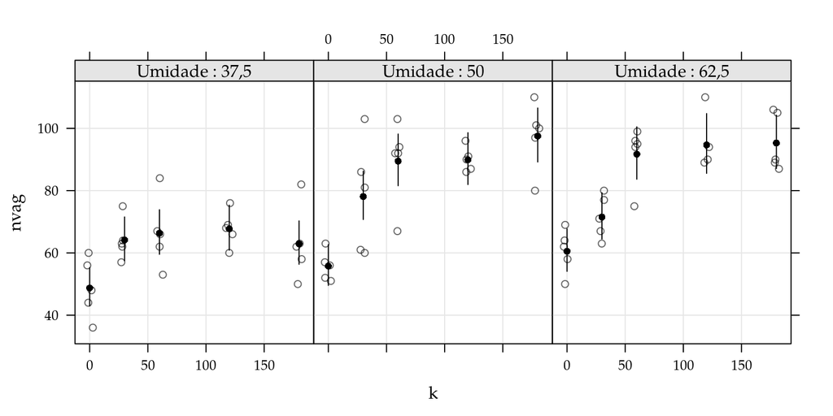

Figure 2.1: Intervalos de confiança para os diferentes níveis de adubação potássica combinados com os míveis de umidade do solo.

## 2.4 Comparações múltiplas

```r
#-----------------------------------------------------------------------
# Comparações múltiplas.

# Constrói as matrizes de contrastes para comparação das doses dentro de
# cada umidade
L <- by(X, INDICES = pred$umid, FUN = as.matrix)
L <- lapply(L, "rownames<-", levels(soja$K))
K <- lapply(L, apc)
K
```

```
## $`37,5`
##         (Intercept) blocII blocIII blocIV blocV umid50 umid62,5 K30 K60
## 0-30              0      0       0      0     0      0        0  -1   0
## 0-60              0      0       0      0     0      0        0   0  -1
## 0-120             0      0       0      0     0      0        0   0   0
## 0-180             0      0       0      0     0      0        0   0   0
## 30-60             0      0       0      0     0      0        0   1  -1
## 30-120            0      0       0      0     0      0        0   1   0
## 30-180            0      0       0      0     0      0        0   1   0
## 60-120            0      0       0      0     0      0        0   0   1
## 60-180            0      0       0      0     0      0        0   0   1
## 120-180           0      0       0      0     0      0        0   0   0
##         K120 K180 umid50:K30 umid62,5:K30 umid50:K60 umid62,5:K60
## 0-30       0    0          0            0          0            0
## 0-60       0    0          0            0          0            0
## 0-120     -1    0          0            0          0            0
## 0-180      0   -1          0            0          0            0
## 30-60      0    0          0            0          0            0
## 30-120    -1    0          0            0          0            0
## 30-180     0   -1          0            0          0            0
## 60-120    -1    0          0            0          0            0
## 60-180     0   -1          0            0          0            0
## 120-180    1   -1          0            0          0            0
##         umid50:K120 umid62,5:K120 umid50:K180 umid62,5:K180
## 0-30              0             0           0             0
## 0-60              0             0           0             0
## 0-120             0             0           0             0
## 0-180             0             0           0             0
## 30-60             0             0           0             0
## 30-120            0             0           0             0
## 30-180            0             0           0             0
## 60-120            0             0           0             0
## 60-180            0             0           0             0
## 120-180           0             0           0             0
##
## $`50`
##         (Intercept) blocII blocIII blocIV blocV umid50 umid62,5 K30 K60
## 0-30              0      0       0      0     0      0        0  -1   0
## 0-60              0      0       0      0     0      0        0   0  -1
## 0-120             0      0       0      0     0      0        0   0   0
```

[output cut: 49 more lines]

```
## 30-180     0   -1          0            1          0            0
## 60-120    -1    0          0            0          0            1
## 60-180     0   -1          0            0          0            1
## 120-180    1   -1          0            0          0            0
##         umid50:K120 umid62,5:K120 umid50:K180 umid62,5:K180
## 0-30              0             0           0             0
## 0-60              0             0           0             0
## 0-120             0            -1           0             0
## 0-180             0             0           0            -1
## 30-60             0             0           0             0
## 30-120            0            -1           0             0
## 30-180            0             0           0            -1
## 60-120            0            -1           0             0
## 60-180            0             0           0            -1
## 120-180           0             1           0            -1
```

```r
# Realiza as comparações múltiplas para cada nível de umidade
comps <- lapply(K, FUN = function(k) {
    glht(model = model, linfct = k)
})
```

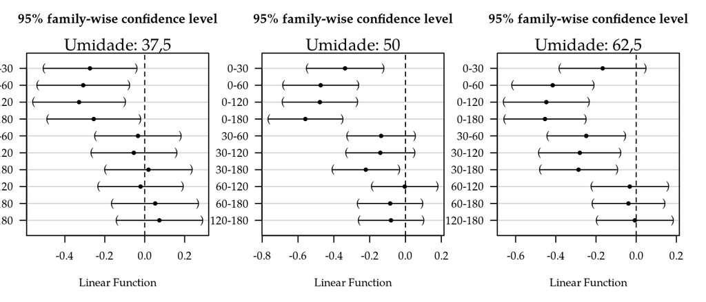

Figure 2.2: Intervalos de confiança para as comparações múltiplas entre doses dentro de cada nível de umidade.

Como resultados complementares ao gráfico apresentado na Figura 2.2 tempos as estimativas dos contrastes com seus respectivos erros padrão e testes de hipótese corrigidos pelo método de Bonferroni

```r
# Estimativas dos contrates
lapply(comps, summary, test = adjusted(type = "bonferroni"))
```

```
## $`37,5`
##
##   Simultaneous Tests for General Linear Hypotheses
##
## Fit: glm(formula = nvag ~ bloc + umid * K, family = poisson, data = soja)
##
## Linear Hypotheses:
##              Estimate Std. Error z value Pr(>|z|)
## 0-30 == 0    -0.27427    0.08493  -3.229 0.012410 *
## 0-60 == 0    -0.30797    0.08432  -3.652 0.002600 **
## 0-120 == 0   -0.32883    0.08395  -3.917 0.000897 ***
## 0-180 == 0   -0.25540    0.08528  -2.995 0.027459 *
## 30-60 == 0   -0.03369    0.07828  -0.430 1.000000
## 30-120 == 0  -0.05456    0.07788  -0.701 1.000000
## 30-180 == 0   0.01887    0.07931   0.238 1.000000
## 60-120 == 0  -0.02087    0.07721  -0.270 1.000000
## 60-180 == 0   0.05256    0.07866   0.668 1.000000
## 120-180 == 0  0.07343    0.07826   0.938 1.000000
## ---
## Signif. codes:  0 '***' 0.001 '**' 0.01 '*' 0.05 '.' 0.1 ' ' 1
## (Adjusted p values reported -- bonferroni method)
##
##
## $`50`
##
##   Simultaneous Tests for General Linear Hypotheses
##
## Fit: glm(formula = nvag ~ bloc + umid * K, family = poisson, data = soja)
##
## Linear Hypotheses:
##               Estimate Std. Error z value Pr(>|z|)
## 0-30 == 0    -0.337496   0.078369  -4.306 0.000166 ***
## 0-60 == 0    -0.473581   0.076265  -6.210 5.31e-09 ***
## 0-120 == 0   -0.478036   0.076200  -6.273 3.53e-09 ***
## 0-180 == 0   -0.559104   0.075056  -7.449 9.39e-13 ***
## 30-60 == 0   -0.136086   0.069208  -1.966 0.492592
## 30-120 == 0  -0.140540   0.069136  -2.033 0.420718
## 30-180 == 0  -0.221608   0.067873  -3.265 0.010945 *
## 60-120 == 0  -0.004454   0.066741  -0.067 1.000000
## 60-180 == 0  -0.085522   0.065432  -1.307 1.000000
```

[output cut: 12 more lines]

```
## Linear Hypotheses:
##               Estimate Std. Error z value Pr(>|z|)
## 0-30 == 0    -0.166800   0.078062  -2.137 0.326164
## 0-60 == 0    -0.415317   0.074020  -5.611 2.01e-07 ***
## 0-120 == 0   -0.447218   0.077181  -5.794 6.86e-08 ***
## 0-180 == 0   -0.453784   0.073463  -6.177 6.53e-09 ***
## 30-60 == 0   -0.248517   0.070512  -3.524 0.004243 **
## 30-120 == 0  -0.280417   0.073823  -3.799 0.001456 **
## 30-180 == 0  -0.286984   0.069927  -4.104 0.000406 ***
## 60-120 == 0  -0.031900   0.069536  -0.459 1.000000
## 60-180 == 0  -0.038466   0.065384  -0.588 1.000000
## 120-180 == 0 -0.006566   0.068942  -0.095 1.000000
## ---
## Signif. codes:  0 '***' 0.001 '**' 0.01 '*' 0.05 '.' 0.1 ' ' 1
## (Adjusted p values reported -- bonferroni method)
```